# Data Science II

Session 3: `sf` Essentials, Choropleths, and Interactive Maps

Bogdan G. Popescu

bgpopescu@tec.mx

Tec de Monterrey

## What You’ll Learn Today

1. What the **`sf`** package is, and the three classes inside it
2. **Joining** a table to boundaries — and the join that silently fails
3. Building a **choropleth** from the result
4. Choosing **colour** — and why `viridis` rather than a rainbow
5. **Classification**: the same data, three schemes, three different stories
6. The **count-versus-rate trap**, and the **small-numbers trap** behind it
7. **Interactive maps** with `leaflet`, embedded in your Quarto report
8. Choosing a **file format**, and writing your layer back out

## Before We Start

Code reads `../data/...`, exactly as in Sessions 1 and 2:

```r
#Step1: Libraries for today
library(sf)          # spatial objects
library(dplyr)       # data wrangling
library(ggplot2)     # static maps
library(classInt)    # classification schemes
library(viridis)     # colour palettes
library(leaflet)     # interactive maps
library(patchwork)   # side-by-side plots

#Step2: Treat lon/lat as planar coordinates -- S2, sf's spherical engine,
#       rejects the small topology errors that real boundary files are full of
sf_use_s2(FALSE)
```

## A Word on `sp`

The first R package for vector data was **`sp`** (2005), with its companions `rgdal` and `rgeos`.

They dominated spatial analysis in R for fifteen years. **`rgdal` and `rgeos` were retired from CRAN in 2023.** `sp` itself survives, but only in maintenance.

**Warning**

Do not start new work with them — but **recognise them**. Most Stack Overflow answers you find were written for `sp`, and anything calling `readOGR()` or `spTransform()` will not run today. This is also the single thing AI gets wrong most often here.

## The `sf` Package

`sf` is the standard package for working with vector data in R.

It relies on three external components: **GDAL** (reading formats), **GEOS** (geometry operations), and **PROJ** (projections).

It contains three classes, and they nest:

- **`sfg`** — a single geometry
- **`sfc`** — a geometry column: many `sfg` plus a CRS
- **`sf`** — a layer: an `sfc` inside a dataframe of attributes

When an error says *“not an `sfc`”*, this is the sentence it is complaining about.

## Today’s Data

**`../data/mexico_homicides.gpkg`** — download first: [mexico_homicides.gpkg](https://www.dropbox.com/scl/fi/icj5i9defldnre0utbbn1/mexico_homicides.gpkg?rlkey=454ow8ad7zfb6u5r3war5qnh8&dl=0)

A GeoPackage with two layers:

| Layer | Rows | Contents |
| --- | --- | --- |
| `states` | 32 | boundaries, population, homicides, rate |
| `municipios` | 2,469 | the same, at municipio level |

- **Homicides** — SESNSP *homicidio doloso*, annual mean over **2021–2023**
- **Population** — INEGI Censo 2020, via the `mxmaps` package
- **Boundaries** — INEGI geometry with `CVEGEO` codes

A three-year mean, not a single year, because one bad year in a small municipio is noise, not signal.

## Reading It In

```r
#Step1: A GeoPackage can hold several layers -- ask what is inside
gpkg <- "../data/mexico_homicides.gpkg"
st_layers(gpkg)$name
```

```
[1] "municipios" "states"
```

```r
#Step2: With several layers you MUST name the one you want, or st_read takes
#       the first and only warns you about it
states <- st_read(gpkg, layer = "states", quiet = TRUE)

#Step3: Look at it
head(st_drop_geometry(states), 3)
```

```
  cve_ent          state_name     pop  homicides      rate
1      01      Aguascalientes 1425607   76.66667  5.377826
2      02     Baja California 3769020 2389.66667 63.402865
3      03 Baja California Sur  798447   37.00000  4.633996
```

# Part A: From a Table to a Choropleth

## Choropleth Maps

A **choropleth** is a thematic map where regions are coloured according to a statistical variable.

The colour carries the number. Everything else on the map is context.

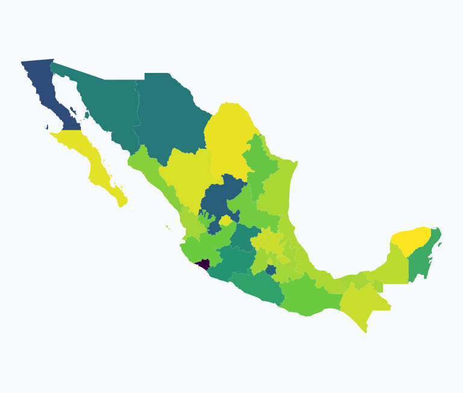

## Three Decisions

Three decisions, and every one of them changes the story:

1. **What variable** — a count, or a rate?
2. **What colours** — which palette, in which direction?
3. **What breaks** — how do continuous values become discrete classes?

Most bad maps are bad because of decision 1 or decision 3.

## The Join Key

Homicides come from SESNSP. Population comes from the census. Boundaries come from INEGI. Three sources, three files.

They are joined on INEGI’s geostatistical code. `31050` is Mérida, Yucatán: `31` for the state, `050` for the municipio.

In our file the state layer calls it **`cve_ent`** and the municipio layer calls it **`cvegeo`** — the same code, one with the municipio digits attached.

**Warning**

**Never join Mexican data on place names.** GADM calls the capital *Distrito Federal*; INEGI calls it *Ciudad de México*. There are two municipios called *Guadalupe*, and several spellings of *Tláhuac*. Codes do not have this problem.

## What a Left Join Does

`left_join(x, y, by = "key")` keeps **every row of `x`**, and pulls in the matching columns from `y`.

A row of `x` with **no match** in `y` is still kept — the new columns just come back `NA`. Nothing is dropped, and nothing warns you.

## The Two Halves

Our GeoPackage arrives pre-joined. Take it apart to see what was joined to what:

```r
#Step1: The boundaries -- the key, a name, and the geometry
boundaries <- states %>%
  select(cve_ent, state_name)
head(boundaries, 3)
```

```
Simple feature collection with 3 features and 2 fields
Geometry type: MULTIPOLYGON
Dimension:     XY
Bounding box:  xmin: -117.1239 ymin: 21.62226 xmax: -101.836 ymax: 32.71865
Geodetic CRS:  WGS 84
  cve_ent          state_name                           geom
1      01      Aguascalientes MULTIPOLYGON (((-102.0681 2...
2      02     Baja California MULTIPOLYGON (((-115.1639 2...
3      03 Baja California Sur MULTIPOLYGON (((-110.8699 2...
```

```r
#Step2: The numbers -- an ordinary dataframe, no geometry at all
rates_table <- states %>%
  st_drop_geometry() %>%
  select(cve_ent, pop, homicides, rate)
head(rates_table, 3)
```

```
  cve_ent     pop  homicides      rate
1      01 1425607   76.66667  5.377826
2      02 3769020 2389.66667 63.402865
3      03  798447   37.00000  4.633996
```

## Doing the Join

```r
#Step1: The sf object goes on the LEFT. That is what keeps the geometry.
joined <- left_join(boundaries, rates_table, by = "cve_ent")
head(joined, 3)
```

```
Simple feature collection with 3 features and 5 fields
Geometry type: MULTIPOLYGON
Dimension:     XY
Bounding box:  xmin: -117.1239 ymin: 21.62226 xmax: -101.836 ymax: 32.71865
Geodetic CRS:  WGS 84
  cve_ent          state_name     pop  homicides      rate
1      01      Aguascalientes 1425607   76.66667  5.377826
2      02     Baja California 3769020 2389.66667 63.402865
3      03 Baja California Sur  798447   37.00000  4.633996
                            geom
1 MULTIPOLYGON (((-102.0681 2...
2 MULTIPOLYGON (((-115.1639 2...
3 MULTIPOLYGON (((-110.8699 2...
```

**Two fields became five**, and `geom` came along without being asked.

## Which Side Goes Left

```r
#Step1: sf on the left -- the result is still an sf object
class(joined)
```

```
[1] "sf"         "data.frame"
```

```r
#Step2: Now put the plain table on the left instead
flipped <- left_join(rates_table, boundaries, by = "cve_ent")

#Step3: The geometry column is still there...
names(flipped)
```

```
[1] "cve_ent"    "pop"        "homicides"  "rate"       "state_name"
[6] "geom"
```

```r
#Step4: ...but the object is not an sf object any more
class(flipped)
```

```
[1] "data.frame"
```

Every column survives, `geom` included. The **class** does not — and `geom_sf()` refuses anything that is not an `sf` object.

## Why `"01"` Is Not `1`

```r
#Step1: The boundary file keeps the state code as text
head(boundaries$cve_ent, 4)
```

```
[1] "01" "02" "03" "04"
```

```r
#Step2: read.csv sees a column of digits and reads it as numbers.
#       A leading zero has nowhere to live inside a number.
as.numeric(head(rates_table$cve_ent, 4))
```

```
[1] 1 2 3 4
```

```r
#Step3: Turning it back into text does not bring the zero back
rates_table_bad <- rates_table %>%
  mutate(cve_ent = as.character(as.numeric(cve_ent)))
head(rates_table_bad$cve_ent, 4)
```

```
[1] "1" "2" "3" "4"
```

```r
#Step4: And to R these are simply two different keys
"01" == "1"
```

```
[1] FALSE
```

## The Trap: Leading Zeros

```r
#Step1: The join runs. No error, no warning.
joined_bad <- left_join(boundaries, rates_table_bad, by = "cve_ent")

#Step2: Nine of the thirty-two matched nothing
sum(is.na(joined_bad$rate))
```

```
[1] 9
```

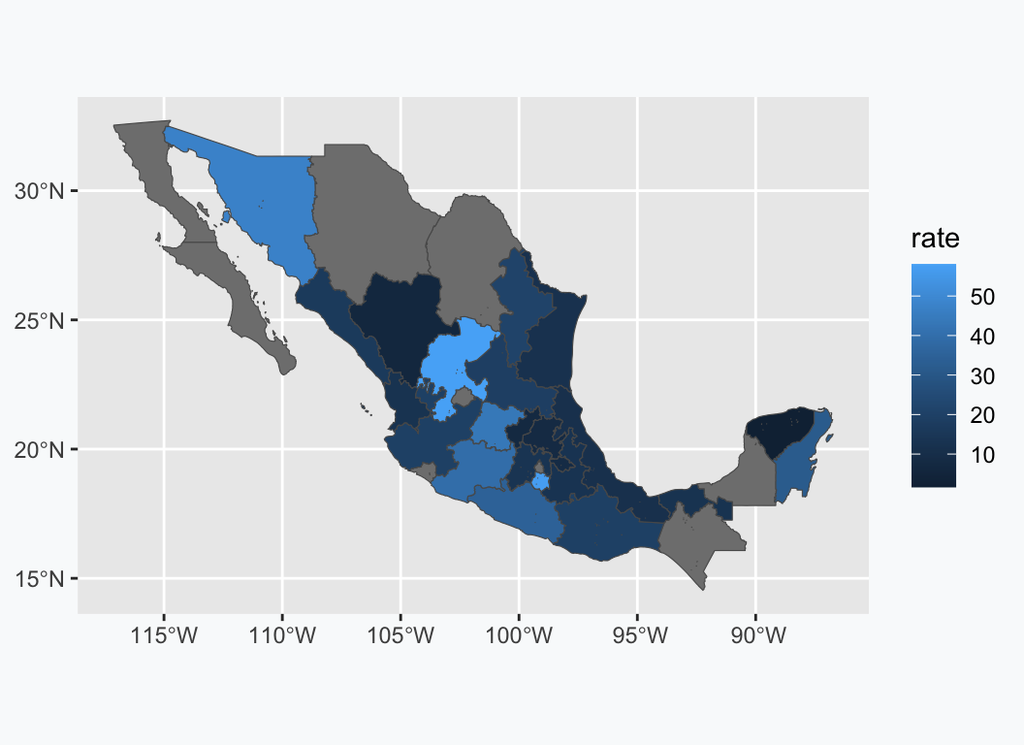

```r
#Step3: And the map draws anyway
ggplot(joined_bad) +
  geom_sf(aes(fill = rate))
```

The grey states are **`01` through `09`**. From `10` on, the keys match.

## Not Losing Nine States

Read code columns as **text**, and the zero survives:

```r
read.csv("estados.csv", colClasses = c(cve_ent = "character"))
```

Or use `readr::read_csv()`, which leaves them alone.

**Important**

Then check `sum(is.na())` after **every** join. One line, and it is the only thing between you and a map with nine silent holes in it.

## Your First Choropleth

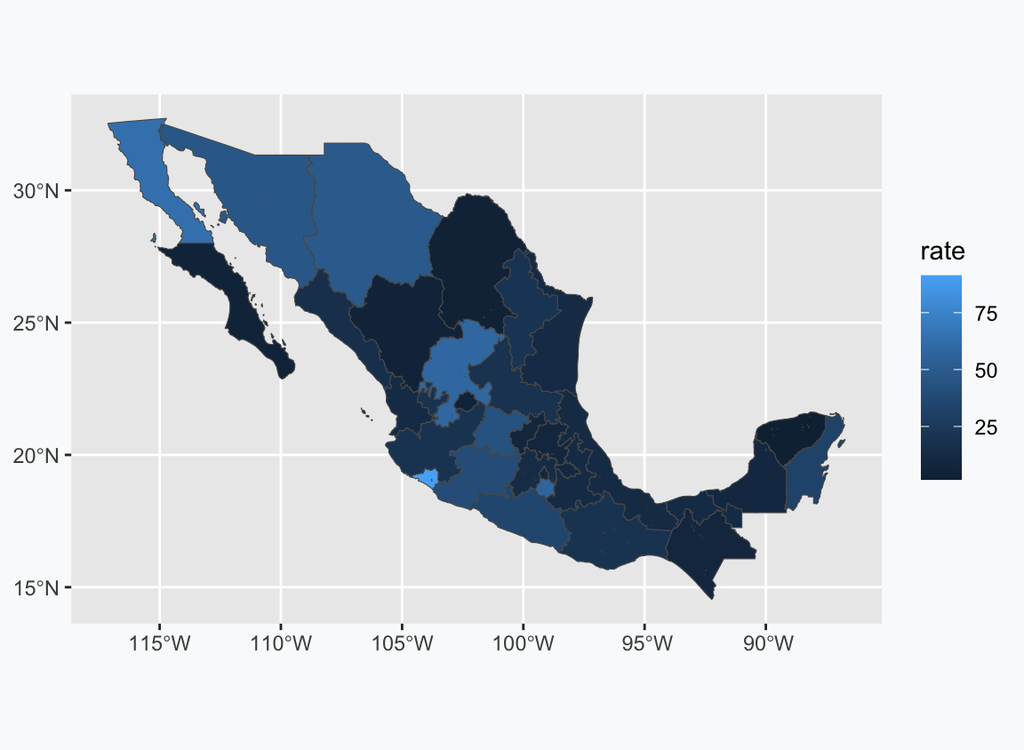

```r
ggplot(states) +
  geom_sf(aes(fill = rate))
```

It works. The north-west and the Pacific centre are visibly worse off than the south-east.

Now we make it *readable*.

# Part B: Colour

## Three Kinds of Palette

| Type | Use when | Example |
| --- | --- | --- |
| **Sequential** | low → high | homicide rate |
| **Diverging** | departure from a midpoint | change since 2015 |
| **Qualitative** | unordered categories | dominant party, land use |

Using a qualitative palette for ordered data — or a rainbow for anything — invents structure that is not in the data.

## The `viridis` Family

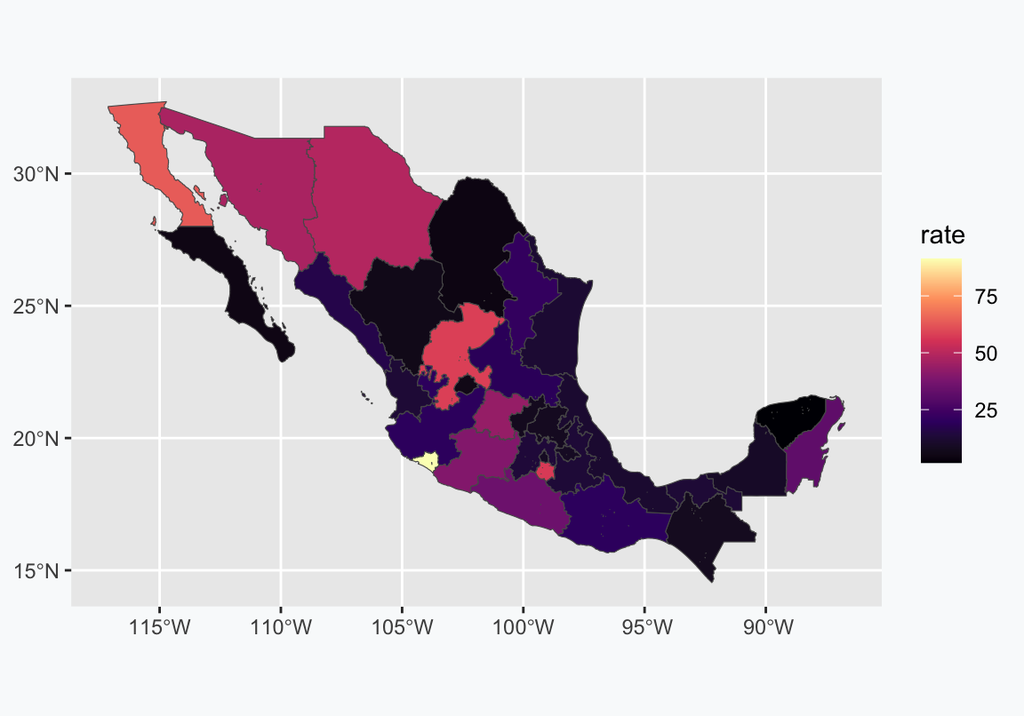

```r
ggplot(states) +
  geom_sf(aes(fill = rate)) +
  scale_fill_viridis_c(option = "magma")
```

## The `viridis` Family

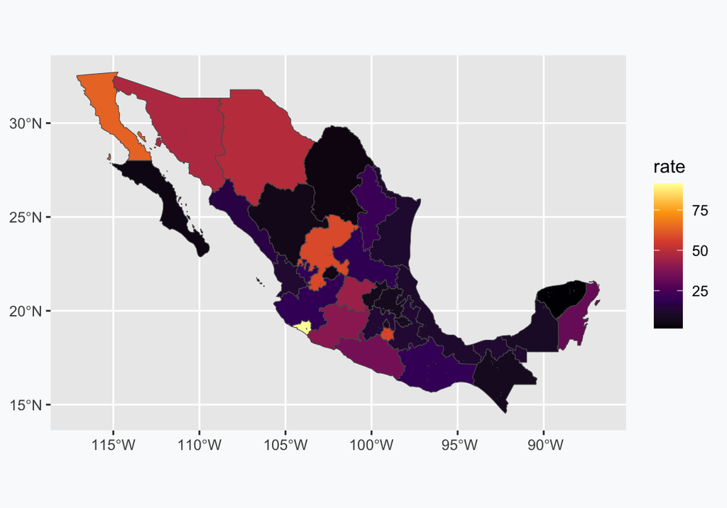

```r
ggplot(states) +
  geom_sf(aes(fill = rate)) +
  scale_fill_viridis_c(option = "inferno")
```

## The `viridis` Family

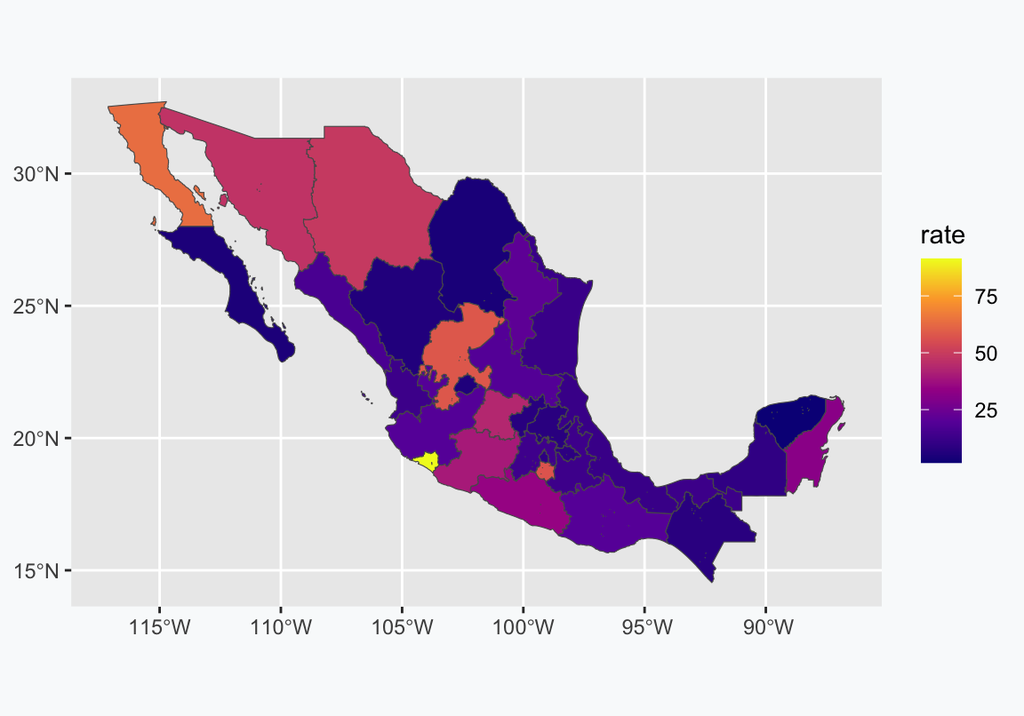

```r
ggplot(states) +
  geom_sf(aes(fill = rate)) +
  scale_fill_viridis_c(option = "plasma")
```

## The `viridis` Family

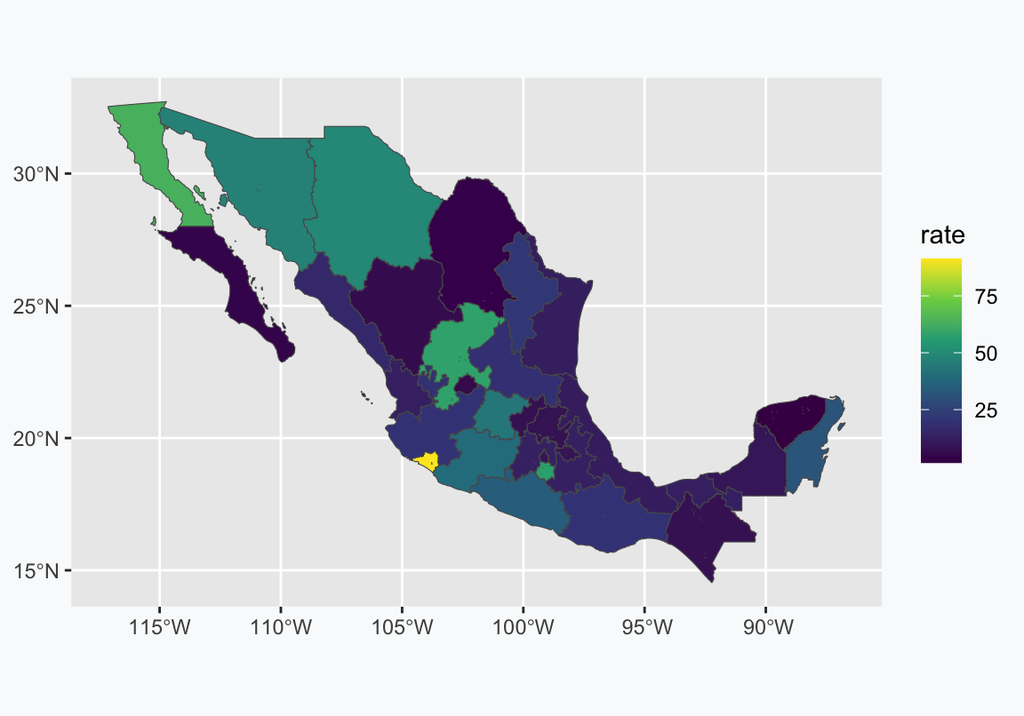

```r
ggplot(states) +
  geom_sf(aes(fill = rate)) +
  scale_fill_viridis_c(option = "viridis")
```

## The `viridis` Family

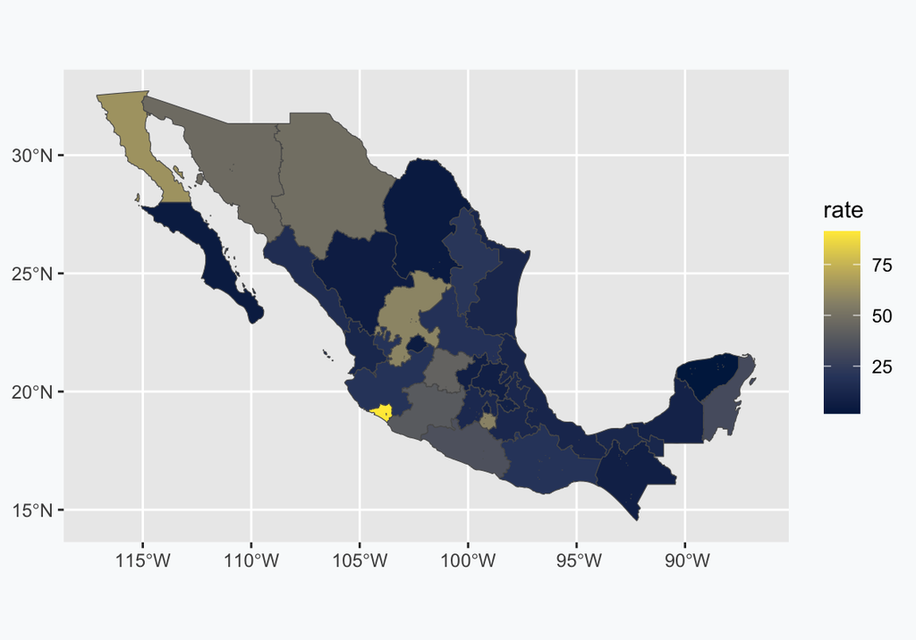

```r
ggplot(states) +
  geom_sf(aes(fill = rate)) +
  scale_fill_viridis_c(option = "cividis")
```

## The `viridis` Family

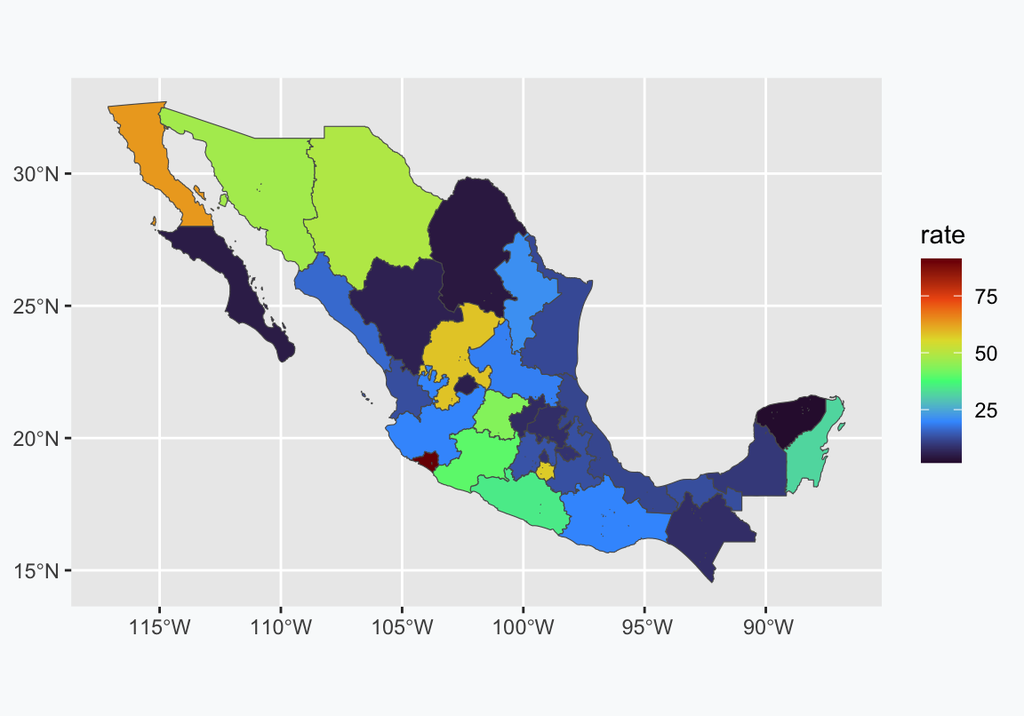

```r
ggplot(states) +
  geom_sf(aes(fill = rate)) +
  scale_fill_viridis_c(option = "turbo")
```

## Why `viridis`?

- **Perceptually uniform** — equal steps in data look like equal steps in colour
- **Colourblind-safe** — about 8% of men have some form of colour vision deficiency
- **Prints in greyscale** — the order survives a black-and-white printer

**Warning**

`turbo` is the exception — it is a rainbow, and it fails all three tests. Look back at the turbo map: the eye jumps to the green states, which are in the *middle* of the distribution. **Do not use it for a policy map.**

## Direction Matters

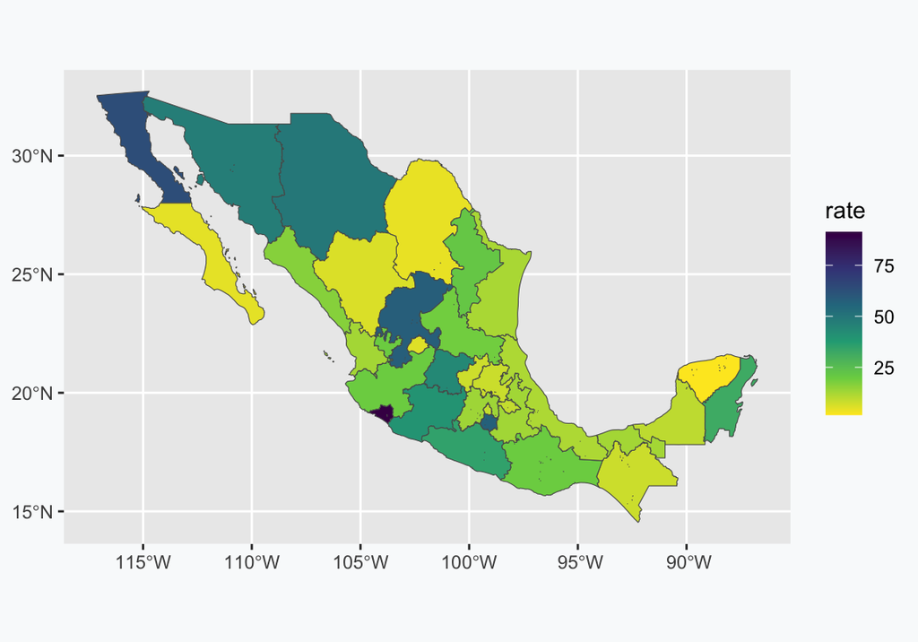

```r
ggplot(states) +
  geom_sf(aes(fill = rate)) +
  scale_fill_viridis_c(direction = -1)
```

`direction = -1` makes **dark mean high**. For a variable like homicide, dark-is-bad matches what readers expect — and it survives photocopying better.

## `_c`, `_b`, or `_d`?

| Function | Gives you | Use for |
| --- | --- | --- |
| `scale_fill_viridis_c()` | **c**ontinuous gradient | smooth variables |
| `scale_fill_viridis_b()` | **b**inned steps | choropleths |
| `scale_fill_viridis_d()` | **d**iscrete categories | factors |

For choropleths you almost always want **binned** — the eye cannot read a continuous ramp accurately. Which raises the real question: *where do the bins go?*

# Part C: Classification

## Continuous to Discrete

A binned choropleth reduces a continuous variable to a handful of colours.

That reduction is a **choice**, and it is the single biggest lever on what the reader sees.

Never pick breaks before you have looked at the distribution.

## The Distribution

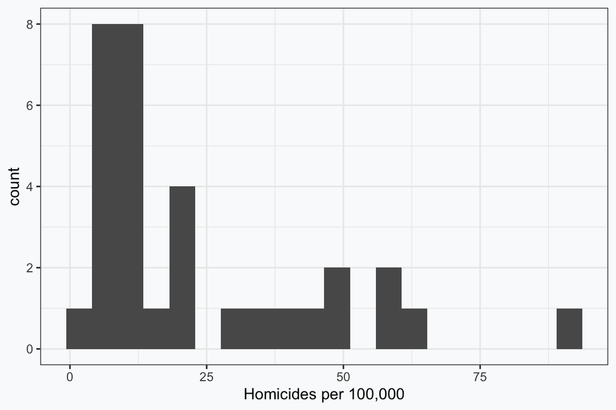

```r
ggplot(states, aes(rate)) +
  geom_histogram(bins = 20) +
  labs(x = "Homicides per 100,000") +
  theme_bw()
```

Right-skewed, but not degenerate. **Mean 23.7, standard deviation 21.7.** Eleven states are below 10; four are above 50.

## `classInt`: Three Ways to Cut

```r
#Step1: Same data, same number of classes, very different cut points
round(classIntervals(states$rate, n = 5, style = "equal")$brks, 1)
```

```
[1]  1.7 19.6 37.5 55.5 73.4 91.3
```

```r
round(classIntervals(states$rate, n = 5, style = "quantile")$brks, 1)
```

```
[1]  1.7  7.9 12.3 19.2 42.7 91.3
```

```r
round(classIntervals(states$rate, n = 5, style = "jenks")$brks, 1)
```

```
[1]  1.7  9.6 21.1 49.0 63.4 91.3
```

Now let us see what each one does to the map.

## What the Three Schemes Do

|  | The rule | The picture |
| --- | --- | --- |
| **Equal interval** | cut the **range** into equal widths | a ruler chopped into five equal pieces |
| **Quantile** | cut so each class holds the **same number of states** | 32 guests seated at 5 tables, about 6 each |
| **Jenks** | cut where the data **already has gaps** | five natural clumps, split where they thin out |

Equal interval is the only one whose legend a reader can **predict**. Quantile is the only one that guarantees **every colour appears**. Jenks is the only one that looks at the **shape** of the data.

None of them is neutral. Choosing a scheme is a claim about what counts as *high*.

## Equal Interval

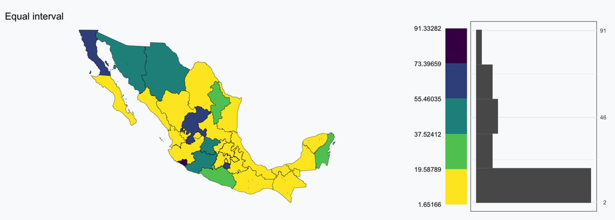

```r
#Step1: Cut the RANGE into five equal-width slices
breaks <- classIntervals(states$rate, n = 5, style = "equal")$brks

#Step2: Use those breaks as the colour steps
ggplot(states) +
  geom_sf(aes(fill = rate)) +
  scale_fill_viridis_b(breaks = breaks, direction = -1)
```

## Equal Interval: What It Does

```r
breaks <- classIntervals(states$rate, n = 5, style = "equal")$brks
table(cut(states$rate, breaks = breaks, include.lowest = TRUE))
```

```
[1.65,19.6] (19.6,37.5] (37.5,55.5] (55.5,73.4] (73.4,91.3]
         21           3           4           3           1
```

**Twenty-one of thirty-two states in the first class.** Equal interval divides the *range*, and the range is stretched by Colima at 91.

Use it when data are roughly **uniform**, or when round-number breaks matter more than resolution.

## Quantile

```r
#Step1: Cut so each class holds the same NUMBER of states
breaks <- classIntervals(states$rate, n = 5, style = "quantile")$brks
```

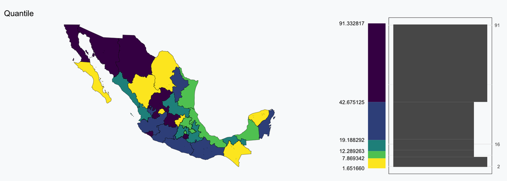

```r
breaks <- classIntervals(states$rate, n = 5, style = "quantile")$brks
table(cut(states$rate, breaks = breaks, include.lowest = TRUE))
```

```
[1.65,7.87] (7.87,12.3] (12.3,19.2] (19.2,42.7] (42.7,91.3]
          7           6           6           6           7
```

## Quantile: The Trade-Off

Six or seven states per class, so the whole map varies and you can read the middle of the distribution.

But look at the colour bar: the swatches are wildly unequal in width. The top class runs from **43 to 91**; the bottom from **1.7 to 8**.

**Warning**

Quantile maps make **rank** visible and **magnitude** invisible. A state at 44 and a state at 91 get the same colour, though one is twice as violent.

## Jenks Natural Breaks

```r
#Step1: Let the algorithm find the gaps in the distribution
breaks <- classIntervals(states$rate, n = 5, style = "jenks")$brks
```

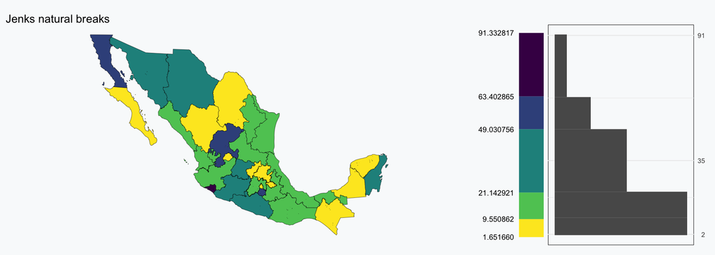

Jenks minimises variance *within* classes and maximises it *between* them — it puts the cuts where the data already has gaps. Here: **11, 11, 6, 3, 1**.

## Which Should You Use?

| Scheme | Good when | Fails when |
| --- | --- | --- |
| **Equal interval** | data are uniform; breaks must be round numbers | outliers stretch the range |
| **Quantile** | you care about rank; want a map that varies | magnitude matters |
| **Std. deviation** | data are symmetric; diverging maps | data are skewed |
| **Jenks** | you want the data’s own structure | maps must be comparable |

**Important**

If you make **several maps that must be compared** — 2015 next to 2023, say — fix the breaks by hand and reuse them. Jenks chooses different cuts for every map, and the maps stop being comparable.

# Part D: Counts, Rates, and Small Numbers

## The Most Common Mistake

```r
#Step1: The five states with the most homicides
states %>%
  st_drop_geometry() %>%
  arrange(desc(homicides)) %>%
  transmute(state_name, homicides = round(homicides), rate = round(rate, 1)) %>%
  head(5)
```

```
       state_name homicides rate
1      Guanajuato      2679 43.4
2 Baja California      2390 63.4
3          México      2286 13.5
4       Michoacán      1880 39.6
5       Chihuahua      1835 49.0
```

## The Most Common Mistake

```r
#Step2: Now the five states with the highest rate
states %>%
  st_drop_geometry() %>%
  arrange(desc(rate)) %>%
  transmute(state_name, homicides = round(homicides), rate = round(rate, 1)) %>%
  head(5)
```

```
       state_name homicides rate
1          Colima       668 91.3
2 Baja California      2390 63.4
3       Zacatecas       941 58.0
4         Morelos      1126 57.1
5       Chihuahua      1835 49.0
```

Almost none of the same states.

## Two Different Countries

By **count**, the State of México is third — 2,286 homicides a year.

By **rate**, it is 13.5 per 100,000, well below the national average. It has 17 million people.

**Colima** has 668 homicides — barely a quarter of México’s — and the worst rate in the country at 91.3.

**Important**

A count map of almost any human event is, mostly, a map of **where the people are**. Almost always, you want a rate.

## Count and Rate Compared

```r
#Step1: Jenks breaks for each variable separately
breaks_count <- classIntervals(states$homicides, n = 5, style = "jenks")$brks
breaks_rate <- classIntervals(states$rate,      n = 5, style = "jenks")$brks

#Step2: One map each, side by side with patchwork
map_count <- ggplot(states) + geom_sf(aes(fill = homicides)) +
  scale_fill_viridis_b(breaks = unique(breaks_count), direction = -1) + ggtitle("Count")
map_rate <- ggplot(states) + geom_sf(aes(fill = rate)) +
  scale_fill_viridis_b(breaks = unique(breaks_rate), direction = -1) + ggtitle("Per 100,000")

map_count | map_rate
```

## Count and Rate Compared

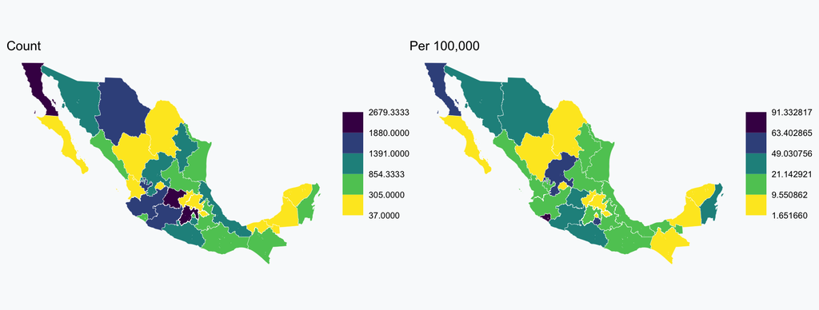

## But Rates Have Their Own Trap

```r
#Step1: Same file, the other layer -- 2,469 units instead of 32
municipios <- st_read(gpkg, layer = "municipios", quiet = TRUE)

#Step2: The five worst rates in the country
municipios %>%
  st_drop_geometry() %>%
  arrange(desc(rate)) %>%
  transmute(municipio_name, state_name, pop,
            homicides = round(homicides, 1), rate = round(rate)) %>%
  head(5)
```

```
           municipio_name state_name  pop homicides rate
1             Doctor Coss Nuevo León 1360      10.0  735
2                 Oquitoa     Sonora  496       1.7  336
3     Sitio de Xitlapehua     Oaxaca  713       1.7  234
4 Santa María Mixtequilla     Oaxaca 4690       9.3  199
5 General Enrique Estrada  Zacatecas 6644      13.0  196
```

## The Small-Numbers Problem

**Doctor Coss, Nuevo León** has the worst homicide rate in Mexico: 735 per 100,000 — eight times Colima.

It has **1,360 inhabitants** and averaged **10 homicides a year**. One more incident moves the rate by 74 points.

**Warning**

A rate with a tiny denominator is **unstable**, not extreme. Ranking municipios by raw rate puts the smallest ones on top almost every time — and a map of it is a map of small populations.

## What To Do About It

- **Pool years** — we already used a three-year mean rather than one year
- **Suppress small denominators** — grey out units below a population threshold and say so in the caption
- **Aggregate** — report at state level where municipio counts are thin
- **Smooth** — empirical Bayes shrinks unreliable rates toward the regional mean

The map on the next slide does the simplest of these: it shows municipios, but greys out those under 10,000 people.

## Municipios, With Small Ones Suppressed

```r
#Step1: Flag the units we do not trust
municipios <- municipios %>%
  mutate(rate_shown = ifelse(pop < 10000, NA, rate))

#Step2: na.value gives the suppressed units their own colour
ggplot(municipios) +
  geom_sf(aes(fill = rate_shown), colour = NA) +
  scale_fill_viridis_b(breaks = c(0, 10, 25, 50, 100), direction = -1,
                       na.value = "grey85", name = "per 100,000")
```

## Municipios, With Small Ones Suppressed

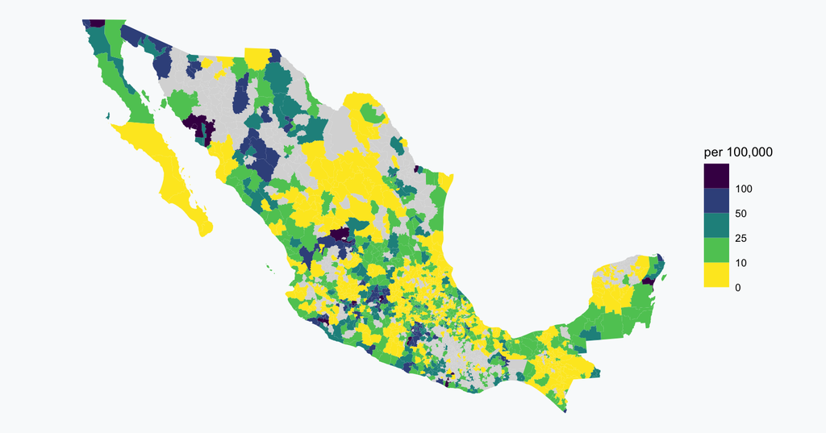

# Part E: Making It Publishable

## Everything a Reader Needs

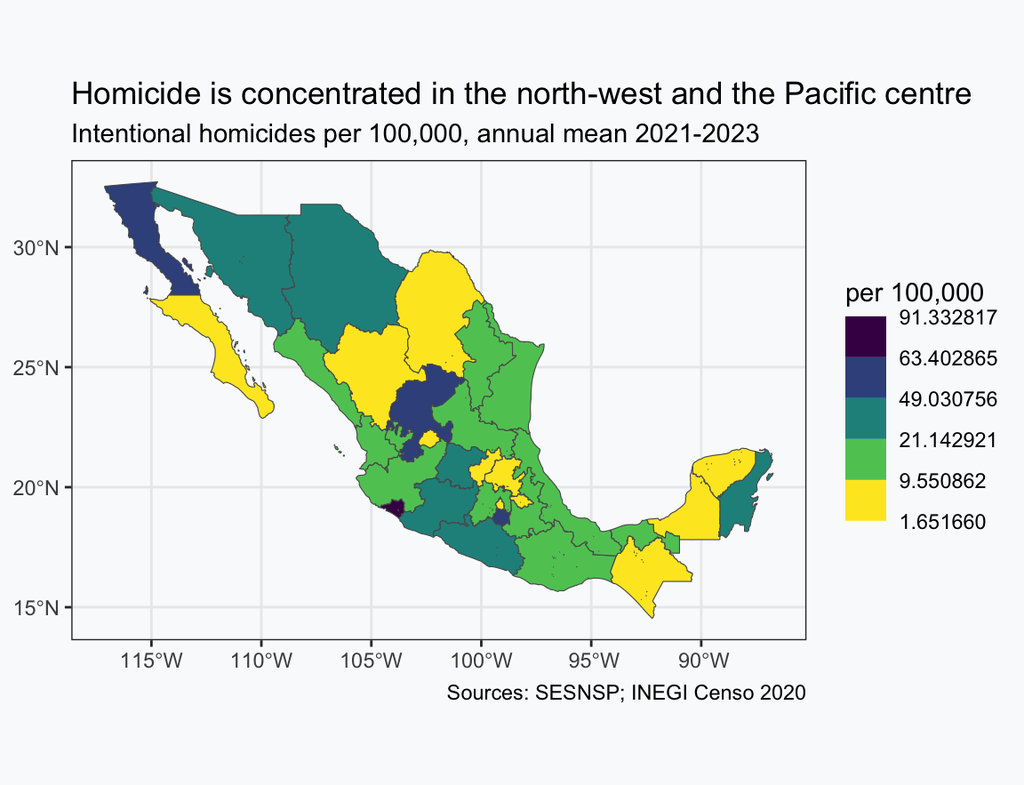

```r
breaks <- classIntervals(states$rate, n = 5,
                       style = "jenks")$brks

ggplot(states) +
  geom_sf(aes(fill = rate)) +
  scale_fill_viridis_b(
    breaks = unique(breaks),
    direction = -1,
    name = "per 100,000") +
  labs(
    title = "Homicide is concentrated in the north-west and the Pacific centre",
    subtitle = "Intentional homicides per 100,000, annual mean 2021-2023",
    caption = "Sources: SESNSP; INEGI Censo 2020") +
  theme_bw()
```

## The Checklist

- **Title states the finding**, not the variable name — “Homicide is concentrated in…”, not “Homicide rate by state”
- **Legend has units** — `per 100,000`, not `rate`
- **Sources in the caption**, always, and the **period** in the subtitle
- **`theme_void()`** — latitude and longitude gridlines are chart junk on a thematic map
- **`coord_sf(crs = 6372)`** — never publish a Mexican map in Web Mercator

## Which Format Should You Use?

|  | Use it when |
| --- | --- |
| **Shapefile** | someone insists — it is the old standard |
| **GeoJSON** | small data, web maps, version control |
| **GeoPackage** | **your default** — one file, no size limit, multiple layers |

**Warning**

Shapefile limitations that will bite you: column names truncated to **10 characters**, a **2 GB** size cap, and no proper support for accented characters. `Nombre_del_Municipio` becomes `Nombre_del`.

## Writing It Back Out

```r
#Step1: The format comes from the extension -- nothing else to set
st_write(states, "homicidios_estados.gpkg", delete_dsn = TRUE)
st_write(states, "homicidios_estados.geojson", delete_dsn = TRUE)
```

`delete_dsn = TRUE` overwrites; without it, a second run errors instead of replacing the file.

**Tip**

Write the **layer you analysed**, not just the picture of it. A reader who has your `.gpkg` can check your work; a reader who has your PNG cannot.

# Part F: Interactive Maps with `leaflet`

## `leaflet`: Three Ingredients

```r
#Step1: leaflet only accepts lon/lat. It does its own projecting, so hand it
#       WGS84 -- give it EPSG:6372 and you get a blank map, with no error.
states_wgs84 <- st_transform(states, 4326)

#Step2: colorBin builds a FUNCTION. Give it a rate, it hands back a colour.
#       Same breaks as the static map, so the two tell the same story.
pal <- colorBin("viridis", domain = states_wgs84$rate,
                bins = unique(breaks), reverse = TRUE)

#Step3: One HTML string per state, in the same row order as the data.
#       <strong> is bold, <br/> is a line break -- this is a tooltip, not a plot.
labels <- sprintf("<strong>%s</strong><br/>%.1f per 100,000",
                  states_wgs84$state_name, states_wgs84$rate) %>%
  lapply(htmltools::HTML)
```

## `leaflet`: Building the Map

```r
#Step4: Start the map and remember the data -- like ggplot(states_wgs84)
leaflet(states_wgs84) %>%
  #Step5: The street map underneath. This is the layer that gives context.
  addTiles() %>%
  #Step6: Draw the states on top of it
  addPolygons(fillColor = ~pal(rate),   # ~ means "look this up in the data"
              fillOpacity = 0.8,        # let the streets show through
              color = "white",          # the border colour
              weight = 1,               # the border thickness
              highlightOptions =        # what happens when the mouse is over
                highlightOptions(weight = 3, color = "#333"),
              label = labels) %>%       # the tooltip from Step3
  #Step7: The key, so the colours mean something
  addLegend(pal = pal, values = ~rate,
            title = "per 100,000", position = "bottomright")
```

The `~` is `leaflet`’s version of `aes()`: *this is a column, go and find it*. Everything without a `~` is a plain value you are setting once.

## The Finished Map

[interactive chart not shown]

Hover over a state. That is the whole point.

## Do Not Forget This

A `leaflet` map is JavaScript. In a Quarto HTML document it depends on external files — unless you say otherwise:

```yaml
---
format:
  html:
    embed-resources: true
---
```

**Important**

This is the trap from **Session 1**, and this is the week it bites. Without `embed-resources: true`, your reader opens the file and sees a **blank white rectangle**.

## What Have We Learned?

- An `sf` object nests three classes: **`sfg`** → **`sfc`** → **`sf`** — a geometry, a geometry column, a table
- A **choropleth** is three decisions: variable, colour, and breaks
- Join Mexican data on the **INEGI code**, never on place names
- The `sf` object goes on the **left** of `left_join`, or you lose the class
- `read.csv` turns `"01"` into `1`: check **`sum(is.na())`** after every join
- **`viridis`** is perceptually uniform, colourblind-safe, and prints in grey — `turbo` is not
- Classification changes the story: equal interval put **21 of 32 states in one class**; quantile spread them 7-6-6-6-7
- A count map is a **population map** in disguise — México is 3rd by count, 13.5 by rate; Colima is 1st by rate with a quarter the homicides
- **`leaflet`** for the reader who wants their own municipio, **`ggplot`** for the printed report — put both in the reto
- But rates on **small denominators** are unstable: Doctor Coss, population 1,360, “leads” the country at 735
- **GeoPackage** is your default format, not shapefile — and `st_write` picks it from the extension